# VH Study 1v2: Random Slope as a Structural Outcome

Author

Michael Hallquist and Zach Vig

Published

August 26, 2026

# 1 Executive summary

Study 1v2 supports the central design decision from the preliminary slope-calibration investigation and substantially sharpens the original Study 1 conclusions. That investigation was an internal design diagnostic, not a study intended for publication. The revised simulation holds the random intercept–slope covariance shape fixed at $\tau_1^2/\tau_0^2=1$, targets marginal posterior slope reliability by changing the Level-1 residual scale, and then introduces the structural effect of the Level-2 predictor $w$. This removes the legacy confounding of low reliability with a nearly degenerate random-effects covariance matrix.

The repaired design behaves well. Oracle, unshrunk-score OLS, stabilized Fuller, and the direct MLM are essentially centered. Their non-null conditional coverage ranges from 94.6% to 94.7%, their typical model SEs closely match empirical sampling SDs, and their null Type I error ranges from 5.2% to 5.4%. Most of the small residual liberality occurs at $N=30$ and is also present for the oracle, so it is a finite-cluster benchmark issue rather than evidence that Stage-1 correction failed.

Three method-specific conclusions are especially clear.

1. **Naive BLUP regression remains a decisive negative control.** Its non-null relative bias is -75.9% at $R=.25$, -54.7% at $R=.50$, and -23.5% at $R=.80$. Conditional coverage deteriorates as $N$ grows because the shrinkage bias persists while intervals narrow.
2. **The Fuller overcoverage reported in the legacy Study 1 analysis does not recur.** Stabilized Fuller has 94.7% non-null conditional coverage and 5.3% null Type I error. In this outcome-error setting, the corrected predictor–outcome measurement covariance is zero and all four Fuller variants are numerically identical.
3. **Lai 2S-PA is conditionally close to nominal but selectively available.** Its non-null conditional coverage is 94.5%, but non-null interval eligibility is only 88.8%. At $R=.25$, eligibility is much lower, especially with 30–50 clusters.

The substantive design conclusion is therefore balanced: posterior reliability is a useful primary information factor once covariance shape is fixed, but estimator behavior still depends on whether the noisy latent score is used as an outcome or as a predictor. Study 1 should not inherit the conservative Fuller and 2S-PA behavior observed in the preliminary investigation’s predictor-error data-generating model.

# 2 Scientific motivation and relation to the calibration repair

Study 1 represents an applied workflow in which a baseline or person-level covariate is used to explain heterogeneity in a within-person process. Examples include asking whether a trait predicts individual differences in affective reactivity, learning rate, or symptom change. The scientific target is not the noisy fitted slope itself; it is the between-person regression linking the covariate to the latent slope. The study asks whether a convenient two-stage analysis recovers that target and its uncertainty.

The preliminary slope-calibration investigation identified two separable questions:

1. Does the reliability manipulation preserve a regular population covariance geometry?
2. Given a regular DGM, does the proposed estimator deliver centered estimates and calibrated intervals?

Study 1v2 answers both questions for a random slope used as a structural **outcome**. Its primary population model can be summarized as

$$y_{it} = u_{0i} + u_{1i}x_{it} + e_{it},
\qquad
u_{1i} = \gamma w_i + \eta_{1i}.$$

The reported target is the standardized structural coefficient $\beta$, equivalently $\gamma$ on the reporting scale used in the simulation. The measurement process determines how precisely $u_{1i}$ is recovered, while the structural decomposition preserves its marginal variance.

This role matters. Classical error in a dependent variable increases sampling variability but does not mechanically attenuate a regression coefficient. A BLUP is different because it is a systematically shrunken conditional expectation. Regressing that shrunken outcome on $w$ attenuates the structural coefficient. Unshrinking restores centering, after which the inferential question is whether the SE accounts adequately for score uncertainty.

That investigation also emphasized residualized-slope reliability, $R_\eta$, when the random intercept and slope jointly enter a structural regression. In Study 1, only the latent slope is the structural outcome. Marginal slope reliability is therefore both the cross-study primary factor and the reliability closest to the focal outcome. We still report $R_\eta$ as a diagnostic, but the design does not require a separate matched-$R_\eta$ arm unless correlation-specific failure appears.

# 3 Design, methods, and completeness

The 720 conditions cross:

- $N=30,50,100,150,300$ clusters;
- $m=3,5,10,25$ balanced observations per cluster;
- target marginal slope reliability $R=.25,.50,.80$;
- random intercept–slope correlations $\rho=-.5,0,.5$; and
- standardized structural effects $\beta=0,.2,.4,.6$.

Each condition contains 1,000 Monte Carlo replications. The primary covariance anchor is $\tau_0^2=\tau_1^2=.81$, so the intercept/slope variance ratio is one. The covariance condition number is one at $\rho=0$ and three at $|\rho|=.5$, far from the ill-conditioned legacy low-slope-variance designs.

The methods have distinct diagnostic roles:

- **Oracle:** regress the known true slope on $w$; this checks the structural truth and finite-$N$ interval benchmark.
- **Naive BLUP:** regress the Stage-1 empirical Bayes slope on $w$; this is the shrinkage negative control.
- **Unshrunk-score OLS and single-subject OLS:** use unshrunken noisy outcomes.
- **Fuller:** use the corrected score and its Stage-1 uncertainty, with zero predictor measurement variance and zero predictor–outcome measurement-error covariance.
- **Lai 2S-PA:** represent the estimated intercept and slope as latent variables in the Stage-2 OpenMx model.
- **Direct MLM:** estimate the $w \times x$ interaction in one mixed model; this is the feasible one-stage benchmark.

Production-output completeness checks.

| check | result |
| --- | --- |
| Expected Study 1v2 conditions | 720 |
| Completed condition summaries | 720 |
| Missing condition IDs | 0 |
| Unexpected condition IDs | 0 |
| Missing condition-method summaries | 0 |
| Unexpected condition-method summaries | 0 |
| Methods per condition | 10 |
| Replications per condition | 1000–1000 |
| Condition-ID range | 2453–3172 |
| Summary artifacts read | 720 |
| Oldest summary artifact (local time) | 2026-08-17 23:10:34 |
| Newest summary artifact (local time) | 2026-08-19 07:28:36 |

All subsequent summaries are computed directly from the exact condition files listed above; no consolidated cache or legacy fallback is used. The render stops if any file, method, replication count, version tag, calibration tag, or fixed-shape invariant is wrong.

# 4 Common terminology and performance metrics

The four v2 reports use the same vocabulary and denominator rules. A **simulation condition** (or *cell*) is one combination of design factors, such as the number of clusters, observations per cluster, reliability, correlation, and true structural effect. Unless a pooled count is explicitly reported, summaries give every condition equal weight. This prevents a method with more eligible fits in easy conditions from implicitly receiving more weight. If an entire condition has no eligible interval, its conditional coverage and SE quantities are undefined and are omitted from the cross-condition average; eligibility and success-and-cover still retain that condition’s failures.

## 4.1 Measurement and model terminology

- The **data-generating model (DGM)** is the population mechanism used to create a simulated data set. An **estimand** is the population quantity the analysis is intended to recover; here it is the standardized structural coefficient, not merely a regression coefficient among estimated scores.
- A **cluster** is the Level-2 unit (for example, a person) observed repeatedly at Level 1. A **random intercept** is that unit’s deviation in level; a **random slope** is its deviation in the within-unit association with the Level-1 predictor. The structural regression asks whether these latent between-unit differences predict, or are predicted by, another variable.
- A **BLUP** (best linear unbiased predictor), also called an empirical Bayes score, is the mixed model’s conditional prediction of a cluster’s random effect. BLUPs deliberately shrink noisy cluster estimates toward the population mean. That improves prediction of an individual random effect but generally makes a subsequent regression on the BLUP target a shrunken quantity rather than the intended latent-effect relation.
- An **unshrunk score** reverses the fitted BLUP shrinkage map to recover a score on the latent random-effect scale. Unshrinking repairs the shrinkage target, but the recovered score remains noisy. If it is used as a predictor, Stage 2 must still account for its measurement-error covariance.
- **Fuller (stabilized)** is the proposed two-stage moment correction. It uses unshrunk scores and their estimated Stage-1 error-covariance matrices, then stabilizes the sampling-variance calculation. The book-equation and alpha-stepdown versions are algebra and tail-sensitivity checks. References to the variance **bread** mean the inverse sensitivity/information component of a sandwich variance estimator, not a second point-estimation correction.
- **Lai 2S-PA** is Lai’s two-stage path-analysis approach: Stage-1 scores and their uncertainty enter a latent-variable path model. **2S-PAA** replaces row-specific uncertainty by an average matrix. **MSEM** is a one-stage multilevel structural equation model. An **oracle** uses the simulated true random effects and supplies a finite-sample benchmark that an applied method cannot attain in real data.
- A **negative control** is a deliberately inadequate estimator whose expected failure has diagnostic value. For example, naive BLUP regression should show shrinkage attenuation. If it did not, the simulation or reporting pipeline would itself require scrutiny.

**Marginal posterior slope reliability** is the primary information target:

$$R = 1 - \frac{E\{V_{i,\mathrm{post}}[\mathrm{slope},\mathrm{slope}]\}}
{G[\mathrm{slope},\mathrm{slope}]}.$$

Here, $G$ is the population random intercept–slope covariance matrix and $V_{i,\mathrm{post}}$ is the remaining posterior uncertainty for cluster $i$ under its observation schedule. Thus, $R=.80$ means that the repeated measurements remove about 80% of the slope’s prior or marginal uncertainty, not that 80% of single observations are signal. **Residualized-slope reliability**, $R_\eta$, applies the same idea to the component of the slope left after its linear association with the random intercept is removed. It can differ from marginal reliability when intercepts and slopes correlate.

An **ICC** is a variance share for an observation under a specified predictor value or contrast. It is not interchangeable with posterior reliability: posterior reliability also uses the number and placement of repeated observations. The v2 **shape-preserving calibration** varies Level-1 residual noise to attain the requested $R$ while holding the slope/intercept variance ratio and intercept–slope correlation fixed. Reliability contrasts therefore do not silently become contrasts in latent covariance geometry.

The **condition number** summarizes how unequal the principal variances of a covariance matrix are: one is perfectly balanced, while a very large value signals near-singularity and numerical sensitivity. A covariance estimate is **positive definite** when it represents strictly positive variation in every linear combination of its latent variables. Zero/negative variances or a nonpositive eigenvalue place a fitted covariance on or beyond an inadmissible boundary.

## 4.2 What each performance quantity answers

[output not shown]

A **Monte Carlo confidence interval** applies the Monte Carlo SE (or a binomial interval for a rate) to a simulation summary. It asks how precisely the simulation has estimated performance. A 95% **Wald confidence interval** in an individual replication is instead the fitted coefficient plus or minus a normal critical value times its model SE; those are the intervals whose coverage is being evaluated.

The standard-error calibration plots require one additional distinction. For each condition $c$, the report computes

$$Q_c =
\frac{\text{mean reported SE among interval-eligible replications}}
{\text{empirical SD of estimates in that same eligible subset}}.$$

The figures then show the **median of $Q_c$ across the nuisance conditions** represented by a point. They do not show a median SE divided by an SD. A ratio near one means that the method’s typical reported uncertainty agrees with its observed repeated-sample variability; values above one indicate typically conservative SE scale, and values below one indicate typically anti-conservative SE scale. The median is used so a few extreme condition-level ratios do not determine the display.

Near-one SE scale is necessary but not sufficient for calibrated intervals. Coverage can still be poor because estimates are biased, standardized errors are skewed or heavy-tailed, SEs covary with estimation error, or only a selected subset of fits is eligible. Accordingly, the reports also inspect the replication-level **standardized error** $(\widehat\beta-\beta)/\widehat{\mathrm{SE}}$. Its SD should be near one when studentization is working; tail summaries reveal failures that a median $Q_c$ can hide.

Fitted posterior reliability and the empirical squared correlation between a true simulated slope and its BLUP answer related but different questions. The first is model-based and computed from fitted covariance/posterior-variance quantities; the second directly measures score recovery in the simulation. They need not be numerically identical in finite samples.

# 5 Calibration and Stage-1 diagnostics

## 5.1 Population manipulation check

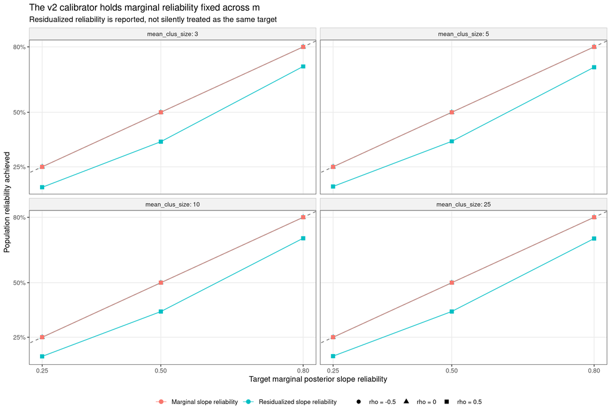

Marginal reliability is attained to numerical precision for every $m$ and $\rho$. Residualized reliability is lower when the intercept and slope correlate. For example, at target $R=.25$ it ranges from approximately .156 to .163 at $|\rho|=.5$, versus .25 at $\rho=0$. This divergence is expected and does not indicate a failed marginal calibration.

The ICCs also change with $m$ even though posterior reliability does not. At $R=.25$, the intercept ICC falls from about .11–.14 at $m=3$ to .01 at $m=25$. This is the same distinction demonstrated by the ICC bridge: posterior reliability incorporates the observation schedule, whereas a fixed single-observation ICC does not hold person-specific slope precision constant.

## 5.2 Fitted reliability and score recovery

The production summaries record quantities that were unavailable in the legacy Study 1 report: fitted marginal and residualized reliability, empirical true-slope/BLUP correlation and $R^2$, and BLUP versus corrected-score bias and RMSE.

Stage-1 recovery diagnostics averaged across m, N, and structural effect conditions.

| Target R | rho | Fitted marginal R | Fitted residualized R | Cor(true, BLUP) | R2(true, BLUP) | BLUP bias | BLUP RMSE | Corrected-score bias | Corrected-score RMSE |
| --- | --- | --- | --- | --- | --- | --- | --- | --- | --- |
| 0.250 | -0.5 | 0.299 | 0.162 | 0.451 | 0.224 | 0.000 | 0.826 | 0.000 | 1.723 |
| 0.250 | 0.0 | 0.295 | 0.216 | 0.447 | 0.221 | -0.000 | 0.820 | -0.000 | 1.545 |
| 0.250 | 0.5 | 0.298 | 0.160 | 0.450 | 0.223 | 0.001 | 0.826 | 0.001 | 1.722 |
| 0.500 | -0.5 | 0.509 | 0.335 | 0.691 | 0.484 | -0.000 | 0.657 | -0.000 | 0.969 |
| 0.500 | 0.0 | 0.499 | 0.463 | 0.693 | 0.487 | 0.000 | 0.655 | 0.000 | 0.896 |
| 0.500 | 0.5 | 0.508 | 0.335 | 0.690 | 0.483 | 0.001 | 0.658 | 0.001 | 0.969 |
| 0.800 | -0.5 | 0.796 | 0.687 | 0.892 | 0.796 | -0.000 | 0.414 | -0.000 | 0.471 |
| 0.800 | 0.0 | 0.795 | 0.787 | 0.893 | 0.797 | 0.001 | 0.413 | 0.001 | 0.456 |
| 0.800 | 0.5 | 0.796 | 0.688 | 0.892 | 0.796 | 0.001 | 0.414 | 0.001 | 0.471 |

The fitted marginal reliability is close to its population target at $R=.50$ and $.80$, but ranges from 0.295 to 0.299 across $\rho$ when the population target is $.25$. The empirical true-slope/BLUP $R^2$ ranges from 0.221 to 0.224 in those cells. The two quantities are related but are not interchangeable: one is computed from the fitted covariance and posterior-variance model, whereas the other is an empirical score-recovery diagnostic.

Both BLUP and corrected scores are centered as estimates of the slope. The cost of unshrinking appears in RMSE: at $R=.25$, corrected-score RMSE ranges from 1.54 to 1.72, compared with 0.82 to 0.83 for the BLUP. Study 1 therefore illustrates the familiar bias–variance distinction at two levels. BLUPs predict individual slopes efficiently, yet regression on them is attenuated; unshrunk scores are noisier person-level estimates, yet their structural regression is centered.

# 6 Bias

## 6.1 Naive BLUP attenuation follows the reliability gradient

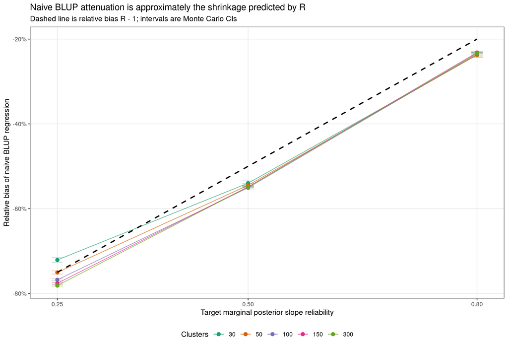

The observed attenuation is slightly stronger than the simple $R-1$ approximation at the medium and high targets, but the theoretical pattern is clear. Increasing $N$ does not remove it. Indeed, the bias becomes easier to detect as the structural SE shrinks.

## 6.2 Corrected and benchmark estimators

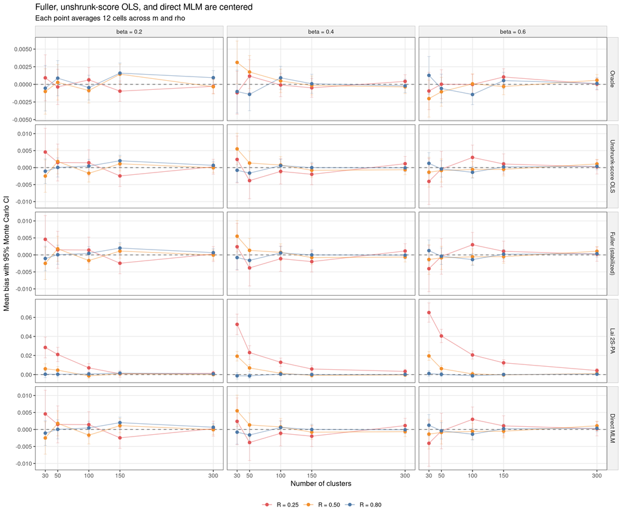

The oracle, unshrunk-score OLS, Fuller, and direct MLM biases are practically zero. Their condition-level mean estimates also agree closely across $\rho$, including the cells where marginal and residualized reliability differ.

2S-PA has modest positive bias concentrated at low reliability and small $N$. Its equal-cell mean bias rises from 0.005 at $\beta=.2$ to 0.011 at $\beta=.6$. That is much smaller than naive BLUP attenuation, but it is systematic enough that conditional coverage should be interpreted jointly with fit eligibility.

# 7 Coverage

## 7.1 Corrected methods and benchmarks

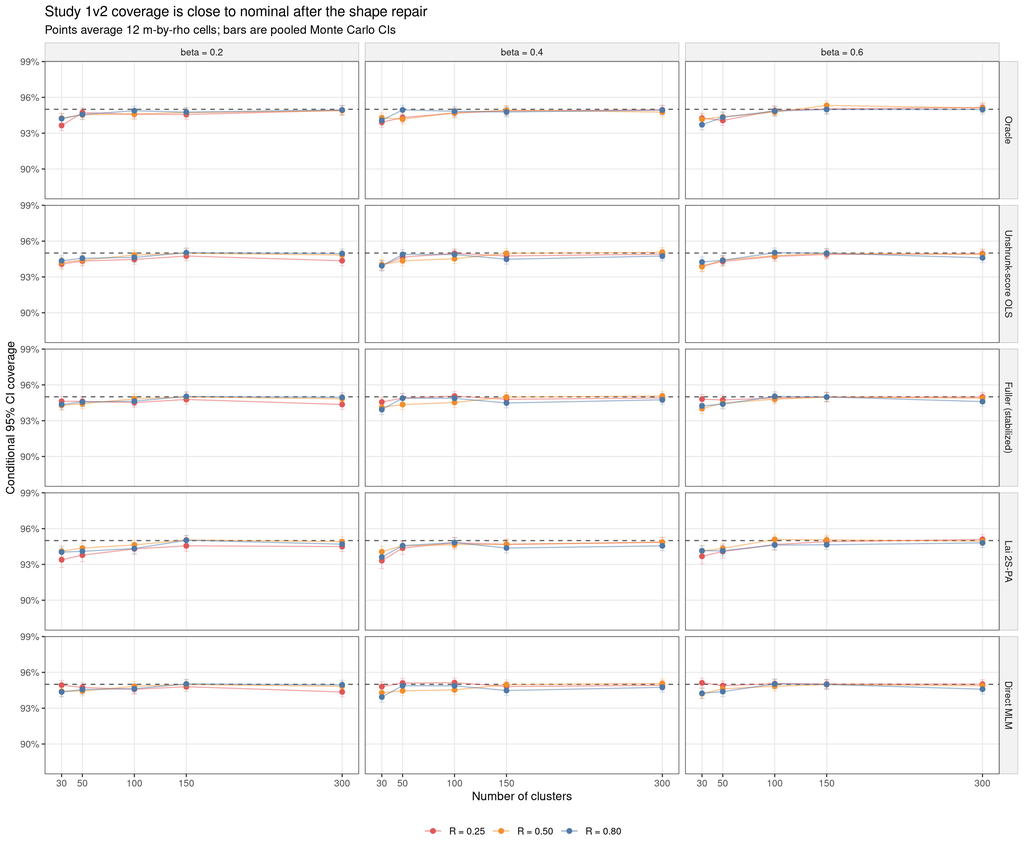

The most important result is negative in a useful sense: there is no broad low-reliability coverage collapse for the corrected methods. Across non-null conditions, unshrunk-score OLS covers 94.6%, Fuller 94.7%, the direct MLM 94.7%, and the oracle 94.6%. Conditional coverage for these methods also remains near nominal within the $R=.25$ conditions.

The small average shortfall from 95% is visible for the oracle as well. Oracle conditional coverage is 94.1% at $N=30$ and 95.0% at $N=300$. That pattern sets the proper benchmark: a feasible method should be compared with the oracle and direct MLM in the same finite-$N$ cell, not only with an abstract horizontal line.

2S-PA’s conditional coverage is also close to 95%, but this statement applies only to successful intervals. Its success-and-cover probability is substantially lower in the low-reliability cells, as shown later.

## 7.2 Naive BLUP coverage

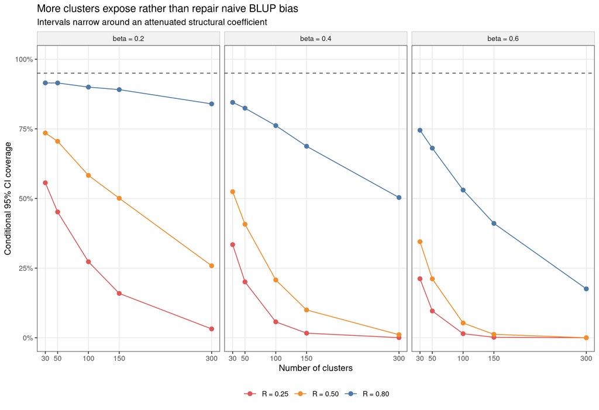

At non-null effects, naive BLUP conditional coverage averages only 39.3%. At $R=.25$ it is 16.0%, compared with 70.8% at $R=.80$. The worsening with larger $N$ is a standard consistency warning: a biased estimator can have decreasing coverage as its nominal precision increases.

# 8 Standard errors and interval mechanism

## 8.1 Reported SE scale versus empirical sampling variability

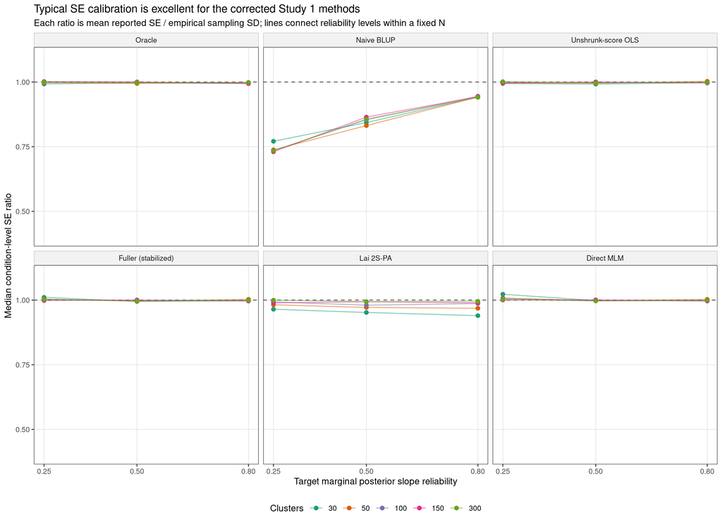

Unshrunk-score OLS, Fuller, direct MLM, and oracle ratios cluster tightly around one. This agrees with their near-nominal coverage. Fuller is not producing the inflated typical SEs that generated overcoverage in the preliminary slope-calibration investigation’s predictor-error setting.

For naive BLUP, the ratio falls as the effect grows and reliability falls. That ratio is not a complete explanation of its coverage failure because the dominant problem is centering: even a perfectly estimated sampling SD would produce an interval centered on the attenuated coefficient.

2S-PA’s condition-level SE ratio is usually only slightly below one. However, a typical ratio can conceal a non-normal standardized-error distribution and a selected fit sample.

## 8.2 Tail-sensitive standardized-error diagnostic

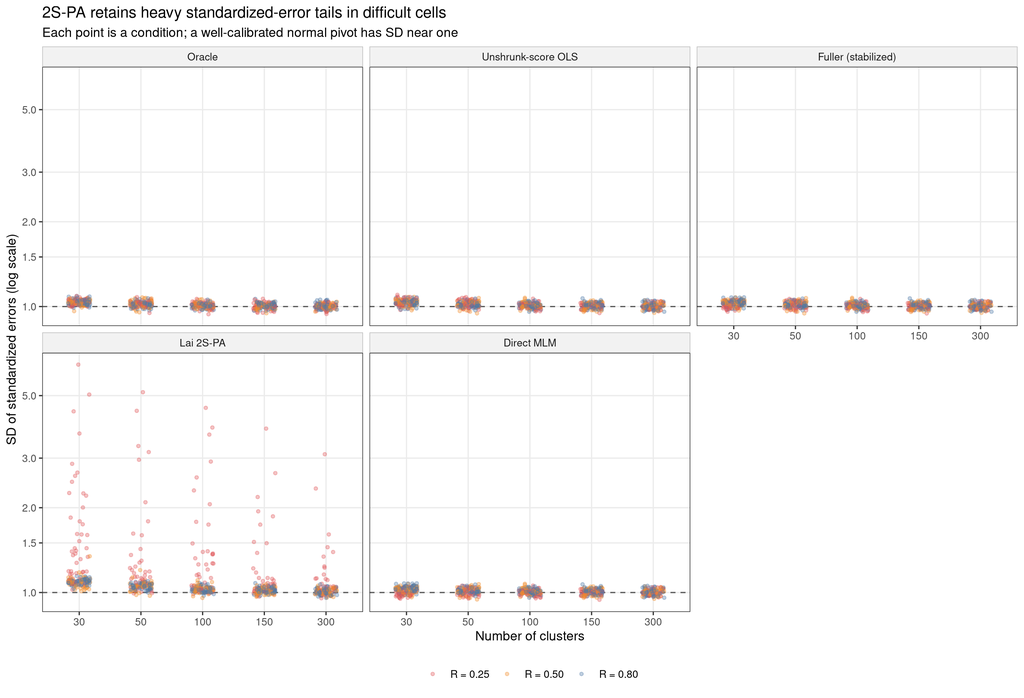

The oracle, unshrunk-score OLS, Fuller, and direct MLM standardized-error SDs remain close to one. For 2S-PA they reach 6.44 in the most difficult cell, and the largest values occur mainly at $R=.25$. These cells do not have enormous 99th-percentile SEs. The problem is instead a combination of selected fits, bias, and a heavy or irregular studentized-error distribution. This is why mean SE, SE tails, standardized errors, and eligibility all belong in the analysis.

## 8.3 Separate centering from interval scale

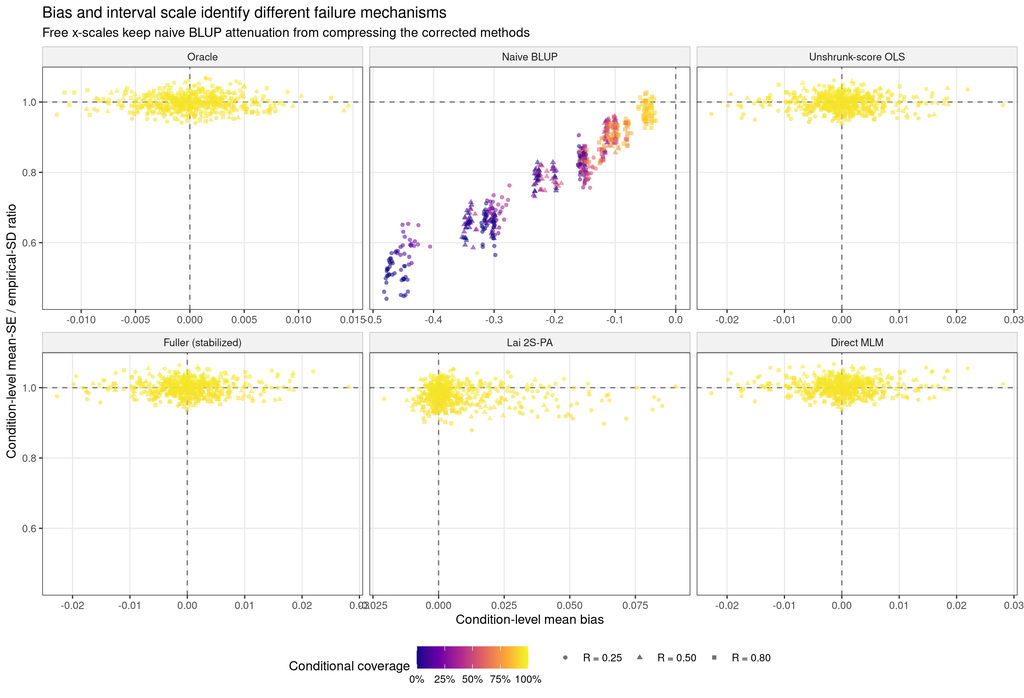

This plot makes the calibration investigation’s diagnostic distinction concrete for Study 1. Naive BLUP lies far from zero bias and often below an SE ratio of one. The corrected methods remain close to both reference lines. 2S-PA is only modestly off center and modestly low in typical SE scale, yet its eligibility and standardized-error tails remain problematic. Coverage alone would not separate these mechanisms.

# 9 Type I error

At $\beta=0$, the null hypothesis is true. Under the two-sided CI-inversion rule, Type I error equals one minus coverage among eligible intervals. The maximum numerical discrepancy in the production summaries is zero.

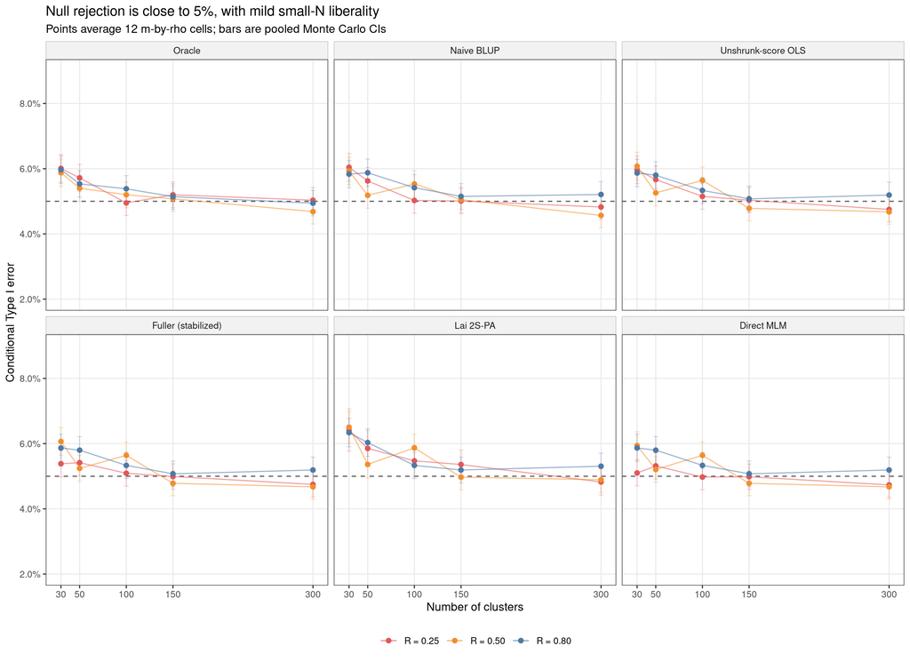

Null diagnostics across 180 cells per method. Cell counts use each cell’s 95% Monte Carlo interval relative to .05.

| Method | Eligibility | Mean null bias | Conditional Type I | Operational Type I | Positive | Negative | Cells above .05 | Cells below .05 |
| --- | --- | --- | --- | --- | --- | --- | --- | --- |
| Unshrunk-score OLS | 100.0% | -0.000 | 5.4% | 5.4% | 2.7% | 2.7% | 24 | 3 |
| Direct MLM | 100.0% | -0.000 | 5.2% | 5.2% | 2.6% | 2.6% | 19 | 3 |
| Fuller (stabilized) | 100.0% | -0.000 | 5.3% | 5.3% | 2.7% | 2.6% | 22 | 3 |
| Lai 2S-PA | 88.6% | 0.000 | 5.6% | 4.9% | 2.8% | 2.7% | 29 | 3 |
| Naive BLUP | 100.0% | -0.000 | 5.4% | 5.4% | 2.7% | 2.7% | 25 | 4 |
| Oracle | 100.0% | -0.000 | 5.3% | 5.3% | 2.6% | 2.7% | 17 | 3 |

The null results are reassuring but should not be summarized as simply “coverage is about 95%.” Mean null bias is negligible and positive and negative rejections are balanced. Fuller is neither strongly conservative nor liberal: its Type I error is 5.3%. The oracle, unshrunk-score OLS, direct MLM, and naive BLUP are similarly close to nominal at the null.

Naive BLUP’s acceptable null test does not rescue it. Shrinkage toward zero cannot attenuate a coefficient whose truth is already zero, so the null cells do not reveal its severe non-null bias. This is an important reason to report Type I error and non-null coverage separately.

2S-PA has conditional Type I error of 5.6%, but operational Type I error of only 4.9%. The difference is not conservatism of the returned intervals; it reflects replications that never return an eligible interval.

# 10 Eligibility and 2S-PA fit selection

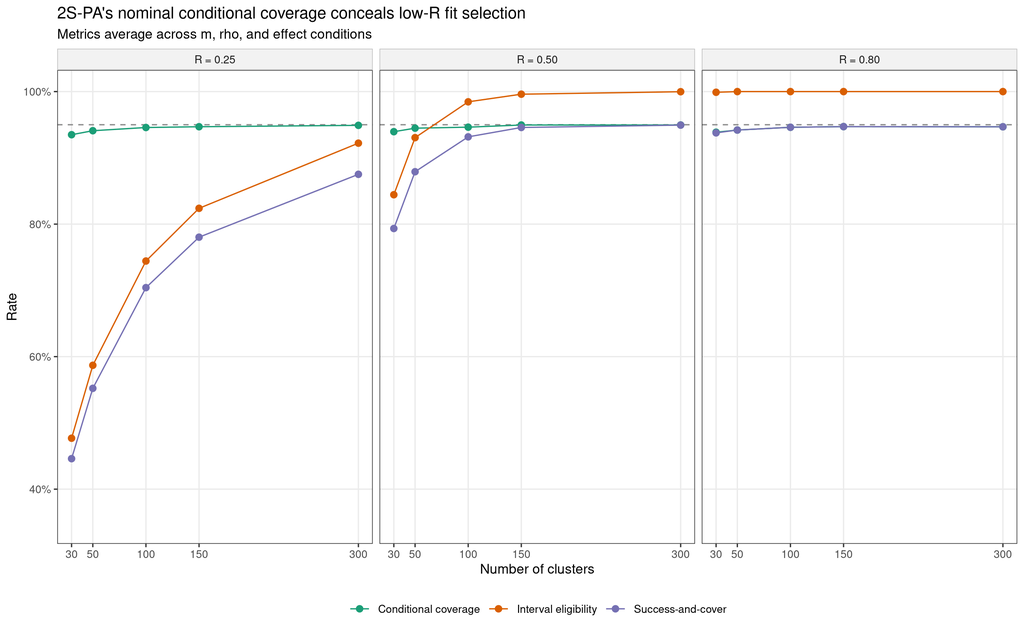

At $N=30$ and $R=.25$, 2S-PA eligibility is only 47.7%. It rises to 92.2% at $N=300$, and is essentially complete at $R=.80$. Correlated intercepts and slopes reduce eligibility further: averaged across the full grid, eligibility is about 86.6% at $|\rho|=.5$ versus 93.0% at $\rho=0$.

The OpenMx latent-covariance boundary diagnostic follows the same gradient. Here, $\Lambda$ is the Stage-1 linear map from the latent intercept–slope vector to its BLUP score vector; its row/column orientation must match that ordering. Correcting that orientation solved an implementation error, but it does not eliminate the finite-sample identification problem of estimating a latent slope variance from weak Stage-1 information. Conditional coverage should remain paired with eligibility and success-and-cover in the paper.

# 11 Direct comparison: stabilized Fuller, Lai 2S-PA, and Direct MLM

The preceding diagnostics establish how each estimator behaves on its own. A publication comparison also needs to ask how the feasible alternatives perform in the **same design conditions**. Stabilized Fuller and Lai 2S-PA are competing two-stage corrections. The direct MLM fits the repeated-measures and structural parts jointly and is therefore the most relevant feasible one-stage benchmark for this outcome-error setting. The comparisons below match methods by condition and judge bias, conditional coverage, interval availability, and SE calibration separately.

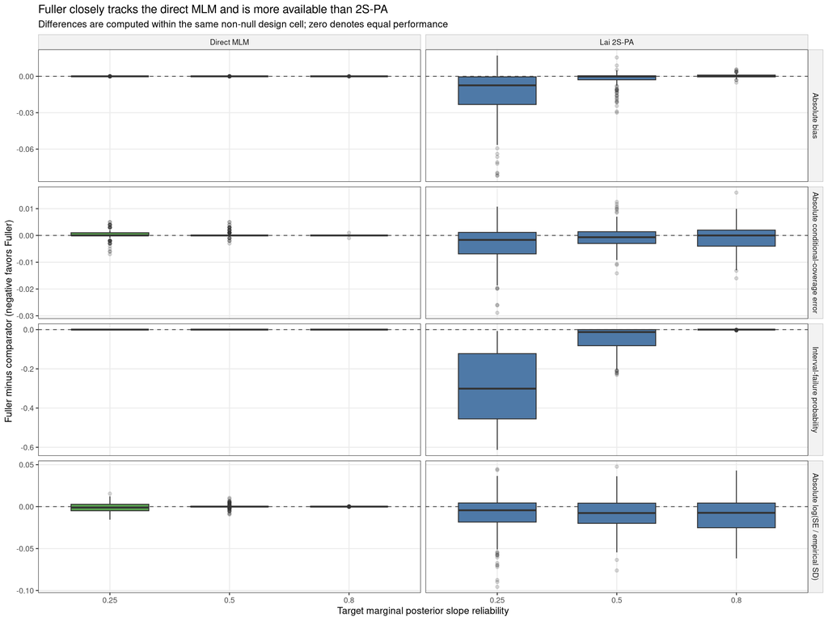

The comparison separates two conclusions that an overall coverage average would blur. Fuller and the direct MLM are fully interval eligible and both are close to centered, so their small matched-cell differences mainly describe finite-sample implementation differences rather than different missing-fit populations. Lai 2S-PA can be conditionally competitive, but at $R=.25$ its eligibility is only 71.2%. Its conditional coverage therefore describes a selected subset, whereas Fuller’s success-and-cover probability at the same reliability is 94.8%.

| Method | Reliability | Mean bias | Mean \|bias\| | Conditional coverage | Interval eligible | Success-and-cover | Median condition-level SE ratio | Null Type I error | Operational null rejection |
| --- | --- | --- | --- | --- | --- | --- | --- | --- | --- |
| Fuller (stabilized) | 0.25 | 0.000 | 0.006 | 94.8% | 100.0% | 94.8% | 1.002 | 5.1% | 5.1% |
| Lai 2S-PA | 0.25 | 0.020 | 0.021 | 94.3% | 71.2% | 67.2% | 0.985 | 5.6% | 3.9% |
| Direct MLM | 0.25 | 0.000 | 0.006 | 94.9% | 100.0% | 94.9% | 1.007 | 5.0% | 5.0% |
| Fuller (stabilized) | 0.50 | 0.000 | 0.004 | 94.6% | 100.0% | 94.6% | 0.997 | 5.3% | 5.3% |
| Lai 2S-PA | 0.50 | 0.004 | 0.007 | 94.6% | 95.1% | 90.0% | 0.980 | 5.5% | 5.2% |
| Direct MLM | 0.50 | 0.000 | 0.004 | 94.7% | 100.0% | 94.7% | 0.998 | 5.2% | 5.2% |
| Fuller (stabilized) | 0.80 | 0.000 | 0.003 | 94.6% | 100.0% | 94.6% | 0.999 | 5.5% | 5.5% |
| Lai 2S-PA | 0.80 | 0.000 | 0.003 | 94.4% | 100.0% | 94.4% | 0.976 | 5.6% | 5.6% |
| Direct MLM | 0.80 | 0.000 | 0.003 | 94.6% | 100.0% | 94.6% | 0.999 | 5.5% | 5.5% |

The appropriate comparative claim is not that Fuller uniformly dominates the joint model. Rather, in Study 1 it reproduces the direct MLM’s favorable bias, coverage, and SE-calibration pattern while retaining a simple two-stage workflow. Its clearest operational advantage over 2S-PA is complete interval availability, especially at low reliability.

# 12 Method-specific conclusions

## 12.1 Oracle and direct MLM

The oracle is centered and close to nominal, validating the structural target. Its mild $N=30$ liberality establishes the finite-sample baseline. The direct MLM is also fully eligible and has nearly the same condition-level mean bias as unshrunk-score OLS. Its SE differs modestly because it estimates the structural interaction and random-effects model jointly. It is the most useful feasible benchmark for Study 1.

## 12.2 Unshrunk-score OLS and single-subject OLS

Unshrunk-score OLS is centered and has typical SE ratios near one. In the balanced Study 1 design, its condition-level coverage, bias, and mean SE are numerically identical to single-subject OLS. The additional closed-form machinery therefore does not change the substantive result here; its importance emerges in studies with more complicated score use or heterogeneous information.

## 12.3 Fuller

Fuller is fully eligible, centered, and near nominal. This is a materially different conclusion from the old Study 1 report and from the preliminary slope-calibration investigation’s predictor-error results. In Study 1 the error-prone score is the outcome, $w$ is observed without measurement error, and the predictor–outcome measurement-error covariance is zero. The Fuller point correction therefore does not subtract an outcome error variance from the predictor covariance, and the variance regularization paths do not activate differently.

All four retained Fuller variants agree exactly across condition-level bias, coverage, mean SE, and eligibility. For the primary Study 1 grid, retaining the variants is useful as an algebra audit but not as four substantively distinct estimators.

## 12.4 Lai 2S-PA

2S-PA has near-nominal conditional coverage and only modest positive bias, but its low-reliability intervals are available for a selected subset of replications. Its standardized-error tails are also heavier than its mean SE/SD ratio suggests. It remains a useful comparator to Lai and a check on the corrected lambda ordering, but operational performance—not conditional coverage alone—should govern its interpretation.

## 12.5 Naive BLUP

Naive BLUP regression behaves exactly as the negative-control logic predicts. It is approximately centered under the null and therefore has acceptable Type I error, but it is attenuated whenever $\beta\ne0$. More clusters make its wrong target more precisely estimated. It should not be presented as a candidate structural estimator.

# 13 Conclusions for the VH study series

Study 1v2 confirms the common calibration framework motivated by the preliminary slope-calibration investigation.

1. **The shape-preserving posterior-reliability calibrator works.** The population marginal target is attained across $m$, the covariance condition number remains one or three, and the corrected estimators no longer show the broad coverage distortions attributed to the legacy design.
2. **Study role matters after calibration.** Fuller’s strong overcoverage in the preliminary slope-calibration investigation’s predictor-error setting is not a universal consequence of Fuller correction. It does not occur when the measured latent slope is an outcome and the structural predictor is error free. The Study 2 predictor-error problem cannot be generalized mechanically to Study 1.
3. **Marginal reliability remains the appropriate shared primary factor.** $R_\eta$ diverges when $\rho\ne0$, but oracle, Fuller, unshrunk-score OLS, and direct-MLM performance changes little across $\rho$. Study 1 supplies no reason to add a full residualized-reliability arm.
4. **The original attenuation conclusion survives; the original Fuller overcoverage conclusion does not.** Naive BLUP attenuation is strong and closely follows reliability. The corrected v2 Fuller intervals are close to nominal.
5. **The minimum reporting set motivated by the calibration investigation remains necessary.** Null Type I error, non-null coverage, bias with Monte Carlo uncertainty, model SE versus empirical SD, standardized-error tails, eligibility, and success-and-cover reveal different aspects of performance.

For a psychological methods audience, the cleanest summary is: posterior reliability describes how well the latent outcome slope can be recovered under the repeated-measures design; shape preservation ensures that its levels are comparable; and the estimator must still be judged according to the role that the recovered slope plays in the structural model. In Study 1, unshrinking plus Fuller performs well, agrees closely with the direct MLM, and removes the attenuation of naive BLUP regression. Lai 2S-PA reaches similar conditional coverage but at a meaningful cost in low-information fit availability.

# 14 Appendix

## 14.1 Compact method-by-effect summary

Equal-cell summaries across 180 conditions per effect and method. Coverage flags use condition-specific 95% Monte Carlo intervals.

| Method | Beta | Eligibility | Mean bias | 95% MC CI | Conditional coverage | Success-and-cover | Median condition-level SE ratio | Cells differing from .95 |
| --- | --- | --- | --- | --- | --- | --- | --- | --- |
| Unshrunk-score OLS | 0.0 | 100.0% | -0.000 | [-0.001, 0.001] | 94.6% | 94.6% | 1.000 | 24 low / 3 high |
| Unshrunk-score OLS | 0.2 | 100.0% | 0.000 | [-0.000, 0.001] | 94.6% | 94.6% | 0.997 | 20 low / 0 high |
| Unshrunk-score OLS | 0.4 | 100.0% | 0.000 | [-0.001, 0.001] | 94.6% | 94.6% | 0.998 | 24 low / 1 high |
| Unshrunk-score OLS | 0.6 | 100.0% | -0.000 | [-0.001, 0.001] | 94.6% | 94.6% | 0.997 | 21 low / 3 high |
| Direct MLM | 0.0 | 100.0% | -0.000 | [-0.001, 0.001] | 94.8% | 94.8% | 1.002 | 19 low / 3 high |
| Direct MLM | 0.2 | 100.0% | 0.000 | [-0.000, 0.001] | 94.7% | 94.7% | 1.001 | 15 low / 0 high |
| Direct MLM | 0.4 | 100.0% | 0.000 | [-0.001, 0.001] | 94.7% | 94.7% | 1.004 | 14 low / 2 high |
| Direct MLM | 0.6 | 100.0% | -0.000 | [-0.001, 0.001] | 94.8% | 94.8% | 1.003 | 11 low / 4 high |
| Fuller (stabilized) | 0.0 | 100.0% | -0.000 | [-0.001, 0.001] | 94.7% | 94.7% | 1.001 | 22 low / 3 high |
| Fuller (stabilized) | 0.2 | 100.0% | 0.000 | [-0.000, 0.001] | 94.7% | 94.7% | 0.999 | 16 low / 0 high |
| Fuller (stabilized) | 0.4 | 100.0% | 0.000 | [-0.001, 0.001] | 94.7% | 94.7% | 1.001 | 18 low / 2 high |
| Fuller (stabilized) | 0.6 | 100.0% | -0.000 | [-0.001, 0.001] | 94.7% | 94.7% | 0.999 | 13 low / 4 high |
| Lai 2S-PA | 0.0 | 88.6% | 0.000 | [-0.001, 0.001] | 94.4% | 83.7% | 0.979 | 29 low / 3 high |
| Lai 2S-PA | 0.2 | 88.7% | 0.005 | [0.004, 0.006] | 94.4% | 83.8% | 0.975 | 28 low / 0 high |
| Lai 2S-PA | 0.4 | 88.7% | 0.008 | [0.007, 0.009] | 94.5% | 83.8% | 0.980 | 26 low / 2 high |
| Lai 2S-PA | 0.6 | 88.9% | 0.011 | [0.010, 0.012] | 94.6% | 84.1% | 0.985 | 21 low / 1 high |
| Naive BLUP | 0.0 | 100.0% | -0.000 | [-0.001, 0.000] | 94.6% | 94.6% | 0.968 | 25 low / 4 high |
| Naive BLUP | 0.2 | 100.0% | -0.102 | [-0.103, -0.102] | 58.1% | 58.1% | 0.914 | 180 low / 0 high |
| Naive BLUP | 0.4 | 100.0% | -0.206 | [-0.206, -0.205] | 36.5% | 36.5% | 0.787 | 180 low / 0 high |
| Naive BLUP | 0.6 | 100.0% | -0.309 | [-0.309, -0.308] | 23.3% | 23.3% | 0.658 | 180 low / 0 high |
| Oracle | 0.0 | 100.0% | -0.000 | [-0.001, 0.000] | 94.7% | 94.7% | 0.999 | 17 low / 3 high |
| Oracle | 0.2 | 100.0% | 0.000 | [-0.000, 0.001] | 94.6% | 94.6% | 0.995 | 20 low / 2 high |
| Oracle | 0.4 | 100.0% | 0.000 | [-0.000, 0.001] | 94.6% | 94.6% | 0.998 | 21 low / 0 high |
| Oracle | 0.6 | 100.0% | -0.000 | [-0.001, 0.000] | 94.7% | 94.7% | 0.999 | 18 low / 2 high |

## 14.2 Correlation sensitivity

Sensitivity to the random intercept–slope correlation.

| Method | rho | Eligibility | Non-null conditional coverage | Non-null bias | Null Type I |
| --- | --- | --- | --- | --- | --- |
| Oracle | -0.5 | 100.0% | 94.7% | 0.000 | 5.3% |
| Oracle | 0.0 | 100.0% | 94.6% | -0.000 | 5.3% |
| Oracle | 0.5 | 100.0% | 94.5% | 0.000 | 5.4% |
| Unshrunk-score OLS | -0.5 | 100.0% | 94.6% | 0.001 | 5.4% |
| Unshrunk-score OLS | 0.0 | 100.0% | 94.6% | -0.000 | 5.3% |
| Unshrunk-score OLS | 0.5 | 100.0% | 94.5% | -0.000 | 5.4% |
| Fuller (stabilized) | -0.5 | 100.0% | 94.7% | 0.001 | 5.3% |
| Fuller (stabilized) | 0.0 | 100.0% | 94.7% | -0.000 | 5.2% |
| Fuller (stabilized) | 0.5 | 100.0% | 94.6% | -0.000 | 5.3% |
| Lai 2S-PA | -0.5 | 86.6% | 94.5% | 0.010 | 5.8% |
| Lai 2S-PA | 0.0 | 93.0% | 94.5% | 0.005 | 5.4% |
| Lai 2S-PA | 0.5 | 86.6% | 94.4% | 0.009 | 5.5% |
| Direct MLM | -0.5 | 100.0% | 94.8% | 0.001 | 5.3% |
| Direct MLM | 0.0 | 100.0% | 94.7% | -0.000 | 5.2% |
| Direct MLM | 0.5 | 100.0% | 94.7% | -0.000 | 5.3% |

## 14.3 Fuller variants

Retained Fuller algebra variants; all are identical in Study 1v2.

| Fuller variant | Eligibility | Null Type I | Non-null conditional coverage | Non-null bias | Median condition-level SE ratio |
| --- | --- | --- | --- | --- | --- |
| Fuller (stabilized) | 100.0% | 5.3% | 94.7% | 0.000 | 1.000 |
| Fuller (book preliminary) | 100.0% | 5.3% | 94.7% | 0.000 | 1.000 |
| Fuller (book equations) | 100.0% | 5.3% | 94.7% | 0.000 | 1.000 |
| Fuller (alpha-stepdown) | 100.0% | 5.3% | 94.7% | 0.000 | 1.000 |

## 14.4 Production artifact provenance

The table describes the recorded environment that generated the condition artifacts, not merely the environment used to render this report.

Distinct production environments recorded for condition IDs 2453–3172 (144 metadata files).

| Pipeline | Git commit | Dirty worktree | Requested replications | R | Mplus | OpenMx | MplusAutomation | lme4 |
| --- | --- | --- | --- | --- | --- | --- | --- | --- |
| openmx_one_row_stage1_covariance_v6_20260817 | 66b464920b3c823bff667ac069698c51a8c87f42 | TRUE | 1000 | R version 4.5.1 (2025-06-13) | Mplus VERSION 8.9 (Linux) | 2.22.11 | 1.4 | 2.0.1 |

**Reproducibility note.** The production metadata record a dirty worktree. The commit hashes are therefore base references, not complete snapshots of the source that generated every artifact. The artifact-level v2, method, replication, and design contracts above still protect this report from legacy or structurally incompatible inputs, but a publication freeze should regenerate the final archive from a clean, tagged commit.